## Results and Discussion

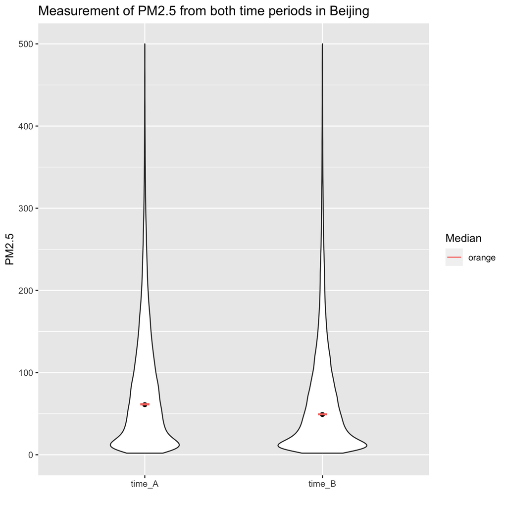

After conducting the permutation test in the difference of medians, we get a p-value of 0.9999976, which is greater than the significance level $\alpha$ = 0.05. The violin plot highlights how close these two median values are. As seen in the plot, the orange line indicates the estimate for each time interval (`time_A` and `time_B`).

A downfall in our data set is that we have a proportion of missing values for the PM2.5 levels. As indicated in the EDA, we have 8739 missing rows, out of the 420768 rows in the `air_data` data set. That is 2.08% of our data. We cannot be certain that this would drastically affect the test statistic and ultimately the p-value. However, it might have reduced the statistical power of our study and produced biased estimates, leading to an invalid conclusion.

A possible extension of our research could occur if we obtain data from 2018 onwards. This would allow us to observe a longer time period to conduct the hypothesis test, and see if there is a broader change in the PM2.5 levels.

Other extensions of our research could include: (1) splitting the 12 districts based on relative distance from the city centre (into two groups), to determine if there is a difference in PM2.5 levels between the metropolis and outskirts; (2) Find data from other cities in China to expand our question to whether there is an improvement in PM2.5 levels across China between 2013-2017.